# Assignment 1

```python
import duckdb
import pandas as pd
from matplotlib import pyplot as plt

pd.set_option('display.max_rows', 500)
pd.set_option('display.max_columns', 500)
```

```python
import os
import urllib.request


URLs = ['https://data.sba.gov/dataset/8aa276e2-6cab-4f86-aca4-a7dde42adf24/resource/738e639c-1fbf-4e16-beb0-a223831011e8/download/public_150k_plus_230930.csv',
        'https://data.sba.gov/dataset/8aa276e2-6cab-4f86-aca4-a7dde42adf24/resource/a7fa66f4-fd2e-433c-8ef9-59780ef60ae5/download/public_up_to_150k_1_230930.csv',
        'https://data.sba.gov/dataset/8aa276e2-6cab-4f86-aca4-a7dde42adf24/resource/7d2308a8-0ac1-48a8-b21b-f9eb373ac417/download/public_up_to_150k_2_230930.csv',
        'https://data.sba.gov/dataset/8aa276e2-6cab-4f86-aca4-a7dde42adf24/resource/5158aae1-066d-4d01-a226-e44ecc9bdda7/download/public_up_to_150k_3_230930.csv',
        'https://data.sba.gov/dataset/8aa276e2-6cab-4f86-aca4-a7dde42adf24/resource/d888bab1-da5b-46f2-bed2-a052d48af246/download/public_up_to_150k_4_230930.csv',
        'https://data.sba.gov/dataset/8aa276e2-6cab-4f86-aca4-a7dde42adf24/resource/ee12d751-2bb4-4343-8330-32311ae4e7c7/download/public_up_to_150k_5_230930.csv',
        'https://data.sba.gov/dataset/8aa276e2-6cab-4f86-aca4-a7dde42adf24/resource/27b874d9-a059-4296-bb74-374294c48616/download/public_up_to_150k_6_230930.csv',
        'https://data.sba.gov/dataset/8aa276e2-6cab-4f86-aca4-a7dde42adf24/resource/434efae0-016a-48da-92dc-c6f113d827c1/download/public_up_to_150k_7_230930.csv',
        'https://data.sba.gov/dataset/8aa276e2-6cab-4f86-aca4-a7dde42adf24/resource/4fc8e993-c3b9-4eb2-b9bb-dfbde9b1fb6f/download/public_up_to_150k_8_230930.csv',
        'https://data.sba.gov/dataset/8aa276e2-6cab-4f86-aca4-a7dde42adf24/resource/7f9c6867-2b55-472e-a4f3-fd0f5f27f790/download/public_up_to_150k_9_230930.csv',
        'https://data.sba.gov/dataset/8aa276e2-6cab-4f86-aca4-a7dde42adf24/resource/a8f2c8b2-facb-4e97-ad5f-7c8736c8b4b6/download/public_up_to_150k_10_230930.csv',
        'https://data.sba.gov/dataset/8aa276e2-6cab-4f86-aca4-a7dde42adf24/resource/6f9787a3-afd6-45b2-b78e-ad0dc097c1c3/download/public_up_to_150k_11_230930.csv',
        'https://data.sba.gov/dataset/8aa276e2-6cab-4f86-aca4-a7dde42adf24/resource/b6528428-fbd9-4ca6-ae08-9e3416f8ee7f/download/public_up_to_150k_12_230930.csv'
       ]

filenames = [i.split('/')[-1] for i in URLs]
print(filenames)
path =  "/Users/yashwanth/Documents/GWU/Sem 3/Data Mining/Class 1/Assignment 1/Datasets/"

for filename, url in zip(filenames, URLs):
    if os.path.isfile(path+filename):
        print(f'file already downloaded: {filename}')
    else:
        print(f'downloading file: {filename}')
        headers = urllib.request.urlretrieve(url, filename=path+filename)
```

```
['public_150k_plus_230930.csv', 'public_up_to_150k_1_230930.csv', 'public_up_to_150k_2_230930.csv', 'public_up_to_150k_3_230930.csv', 'public_up_to_150k_4_230930.csv', 'public_up_to_150k_5_230930.csv', 'public_up_to_150k_6_230930.csv', 'public_up_to_150k_7_230930.csv', 'public_up_to_150k_8_230930.cs…
file already downloaded: public_150k_plus_230930.csv
file already downloaded: public_up_to_150k_1_230930.csv
file already downloaded: public_up_to_150k_2_230930.csv
file already downloaded: public_up_to_150k_3_230930.csv
file already downloaded: public_up_to_150k_4_230930.csv
file already downloaded: public_up_to_150k_5_230930.csv
file already downloaded: public_up_to_150k_6_230930.csv
file already downloaded: public_up_to_150k_7_230930.csv
file already downloaded: public_up_to_150k_8_230930.csv
file already downloaded: public_up_to_150k_9_230930.csv
file already downloaded: public_up_to_150k_10_230930.csv
file already downloaded: public_up_to_150k_11_230930.csv
file already downloaded: public_up_to_150k_12_230930.csv
```

```python
duckdb.sql(f'CREATE TEMPORARY VIEW ppp AS (SELECT * FROM "{path}public*.csv")')
```

# Problem 1:

Download the NAICS Code Descriptions from here: https://drive.google.com/file/d/1c8xw4XJwhdtkQAsEq3rko9wDBAtQ4HWL/view?usp=sharing and ingest them into a table or dataframe. Please include both NAICSCode and the Title in your answers.

Question 1a: Using that data, what are the top 10 industries in the District of Columbia by total count of loans

Question 1b: Using that data, what are the top 10 industries in the District of Columbia by total CurrentApprovalAmount

Question 1c: Using that data, what are the top 10 industries in the District of Columbia by average approved loan amount?

```python
naics_desc_path = "/Users/yashwanth/Documents/GWU/Sem 3/Data Mining/Class 1/Assignment 1/Datasets/2017_NAICS_Descriptions.csv"
naics_desc = pd.read_csv(naics_desc_path)
print(naics_desc.head())
```

```
     Code                                        Title  \
0      11  Agriculture, Forestry, Fishing and HuntingT
1     111                            Crop ProductionT
2    1111                   Oilseed and Grain FarmingT
3   11111                             Soybean FarmingT
4  111110                              Soybean Farming

                                         Description
0  The Sector as a Whole\n\nThe Agriculture, Fore...
1  Industries in the Crop Production subsector gr...
2  This industry group comprises establishments p...
3               See industry description for 111110.
4  This industry comprises establishments primari...
```

```python
duckdb.sql(f'CREATE TEMPORARY VIEW naics_desc AS SELECT * FROM "{naics_desc_path}"')
```

```python
# Question 1a - Top 10 industries in DC bt total count of loan

top10_count = duckdb.sql('''
SELECT
    naics_desc.Title AS industry_title,
    COUNT(ppp.NAICSCode) AS total_loans
FROM
    ppp
JOIN
    naics_desc
ON
    ppp.NAICSCode = naics_desc.Code
WHERE
    ppp.BorrowerState = 'DC'
GROUP BY
    naics_desc.Title
ORDER BY
    total_loans DESC
LIMIT 10
''').df()

print(top10_count)
```

```
FloatProgress(value=0.0, layout=Layout(width='auto'), style=ProgressStyle(bar_color='black'))
```

```
                                      industry_title  total_loans
0                          Full-Service Restaurants          1504
1                                      Taxi Service          1265
2                                     Beauty Salons          1223
3                                 Offices of Lawyers         1117
4  Administrative Management and General Manageme...          746
5          Offices of Real Estate Agents and Brokers          644
6  All Other Professional, Scientific, and Techni...          633
7                       All Other Personal Services           575
8              Other Management Consulting Services           575
9                       Limited-Service Restaurants           564
```

```python
# Question 1b - Top 10 industries in the District of Columbia by total CurrentApprovalAmount

top10_amount = duckdb.sql('''
SELECT
    naics_desc.Title AS industry_title,
    SUM(ppp.CurrentApprovalAmount) AS total_amount
FROM
    ppp
JOIN
    naics_desc
ON
    ppp.NAICSCode = naics_desc.Code
WHERE
    ppp.BorrowerState = 'DC'
GROUP BY
    naics_desc.Title
ORDER BY
    total_amount DESC
LIMIT 10
''').df()

print(top10_amount)
```

```
FloatProgress(value=0.0, layout=Layout(width='auto'), style=ProgressStyle(bar_color='black'))
```

```
                                      industry_title  total_amount
0                          Full-Service Restaurants   3.427401e+08
1                                 Offices of Lawyers  1.871879e+08
2          Hotels (except Casino Hotels) and Motels   9.678859e+07
3  Administrative Management and General Manageme...  9.135773e+07
4               Other Social Advocacy Organizations   8.620500e+07
5                        Professional Organizations   8.512934e+07
6                    Civic and Social Organizations   8.090566e+07
7  All Other Professional, Scientific, and Techni...  7.895135e+07
8                  Elementary and Secondary Schools   7.579556e+07
9                             Business Associations   6.973734e+07
```

```python
# Question 1c -  Top 10 industries in the District of Columbia by average approved loan amount

top10_avg_amount = duckdb.sql('''
SELECT
    naics_desc.Title AS industry_title,
    AVG(ppp.CurrentApprovalAmount) AS avg_amount
FROM
    ppp
JOIN
    naics_desc
ON
    ppp.NAICSCode = naics_desc.Code
WHERE
    ppp.BorrowerState = 'DC'
GROUP BY
    naics_desc.Title
ORDER BY
    avg_amount DESC
LIMIT 10
''').df()

print(top10_avg_amount)
```

```
FloatProgress(value=0.0, layout=Layout(width='auto'), style=ProgressStyle(bar_color='black'))
```

```
                                      industry_title    avg_amount
0  Postharvest Crop Activities (except Cotton Gin...  4.739270e+06
1                   Convention and Visitors Bureaus   1.746473e+06
2                       Satellite Telecommunications  1.449332e+06
3                        Zoos and Botanical Gardens   1.336650e+06
4            Continuing Care Retirement Communities   1.162830e+06
5          Highway, Street, and Bridge Construction   1.134046e+06
6                                           Logging   1.003184e+06
7  Custom Architectural Woodwork and Millwork Man...  8.454965e+05
8  Residential Intellectual and Developmental Dis...  7.938756e+05
9                Administration of Housing Programs   7.540642e+05
```

# Problem 2:

The last results (by average loan amount) is rather wild looking. The top NAICS that I see has only a single, very high dollar loan.

This shows us that sometimes, there are rare values that might be valid but may be outliers. In this case, these business types really do probably have high loan amounts on average, for a variety of reasons. PPP loans were given out based on Payroll, but also other costs, such as mortgage, rent, utilities, etc. Some of the top categories may have qualified for more benefits.

So, let's dig into payroll a bit more.

Question 2a: Make a scatter plot to show whether PAYROLL_PROCEED depends on JobsReported. Please drop the filter for DC

Note: you may want to sample the values to make the plot a little clearer. I used 100,000 points in my plot.

Question 2b: There are 2 unusual patterns in the data, where "too many" scattered dots fall on a straight line. Why do you think theese lines exist? You may need to do some research on PPP loans online. Part of the data mining process involves understanding the context of your data and how it was created.

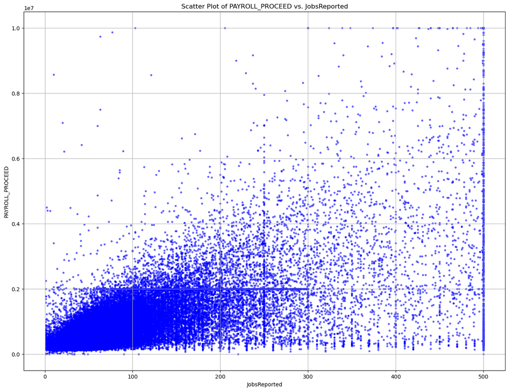

```python
# Question 2a - scatter plot

sample_size = 100000
sampled_data = duckdb.sql(f'''
SELECT
    PAYROLL_PROCEED,
    JobsReported
FROM
    ppp
WHERE
    PAYROLL_PROCEED IS NOT NULL AND JobsReported IS NOT NULL
LIMIT {sample_size}
''').df()

plt.figure(figsize=(16, 12))
plt.scatter(sampled_data['JobsReported'], sampled_data['PAYROLL_PROCEED'], alpha=0.5, c='blue', s=8)
plt.title('Scatter Plot of PAYROLL_PROCEED vs. JobsReported')
plt.xlabel('JobsReported')
plt.ylabel('PAYROLL_PROCEED')
plt.grid(True)
plt.show()
```

Question 2b

The distinct patterns in PPP loan amounts can be explained by a few key factors. First, the way PPP loans were calculated—using payroll expenses and fixed multipliers—led to specific, repeated loan amounts. Businesses often reported payroll and job numbers as rounded figures, creating noticeable lines or clusters when this data is plotted. This rounding likely came from common data entry practices, where standardized forms made it easy for businesses to use approximate numbers.

Another factor is that loans were sometimes issued in fixed amounts or tranches, causing loans to group around certain values. Additionally, the way the data was aggregated at specific intervals contributed to these straight-line patterns. Finally, business size categories and loan caps meant that similar-sized businesses often received similar loan amounts, leading to more clustering. Altogether, these factors explain the distinct, linear patterns seen in the data.

# Problem 3

It seems like there is a relationship between these variables.

One way to measure this relationship is with a "Correlation Coefficient". For continuous variables, such as these, it is common to use the Pearson Correlation Coefficient

In the previous analysis, we measured the mean and standard deviation of a variable. We can use those as the building block for the corrleation.

Where cov(𝑋,𝑌) is the covariance of the two variables:

cov(𝑋,𝑌)=∑𝑖=1𝑛(𝑥𝑖−𝑥¯)(𝑦𝑖−𝑦¯)

What this tells you is the strength of the linear relationship

Question 3a: Calculate the Pearson Correlation between the Payroll and Jobs (you may use a built in function)

Question 3b: What is the correlation between PAYROLL_PROCEED and CurrentApprovalAmount ?

Question 3c: Make a scatter plot of how Payroll and Approval Amount depend on each other? Do you think a simple linear relationship exists between these two variables? Or is there something more complex happening?

```python
# Question 3a - Pearson Correlation between the Payroll and Jobs

from scipy.stats import pearsonr

payroll_jobs_data = duckdb.sql('''
SELECT
    PAYROLL_PROCEED,
    JobsReported
FROM
    ppp
WHERE
    PAYROLL_PROCEED IS NOT NULL AND JobsReported IS NOT NULL
''').df()

corr_payroll_jobs, _ = pearsonr(payroll_jobs_data['PAYROLL_PROCEED'], payroll_jobs_data['JobsReported'])
print(f'Pearson Correlation between PAYROLL_PROCEED and JobsReported: {corr_payroll_jobs}')
```

```
FloatProgress(value=0.0, layout=Layout(width='auto'), style=ProgressStyle(bar_color='black'))
```

```
Pearson Correlation between PAYROLL_PROCEED and JobsReported: 0.7929942141458429
```

```python
# Question 3b - correlation between PAYROLL_PROCEED and CurrentApprovalAmount

payroll_approval_data = duckdb.sql('''
SELECT
    PAYROLL_PROCEED,
    CurrentApprovalAmount
FROM
    ppp
WHERE
    PAYROLL_PROCEED IS NOT NULL AND CurrentApprovalAmount IS NOT NULL
''').df()

corr_payroll_approval, _ = pearsonr(payroll_approval_data['PAYROLL_PROCEED'], payroll_approval_data['CurrentApprovalAmount'])
print(f'Pearson Correlation between PAYROLL_PROCEED and CurrentApprovalAmount: {corr_payroll_approval}')
```

```
FloatProgress(value=0.0, layout=Layout(width='auto'), style=ProgressStyle(bar_color='black'))
```

```
Pearson Correlation between PAYROLL_PROCEED and CurrentApprovalAmount: 0.9961071642353053
```

```
FloatProgress(value=0.0, layout=Layout(width='auto'), style=ProgressStyle(bar_color='black'))
```

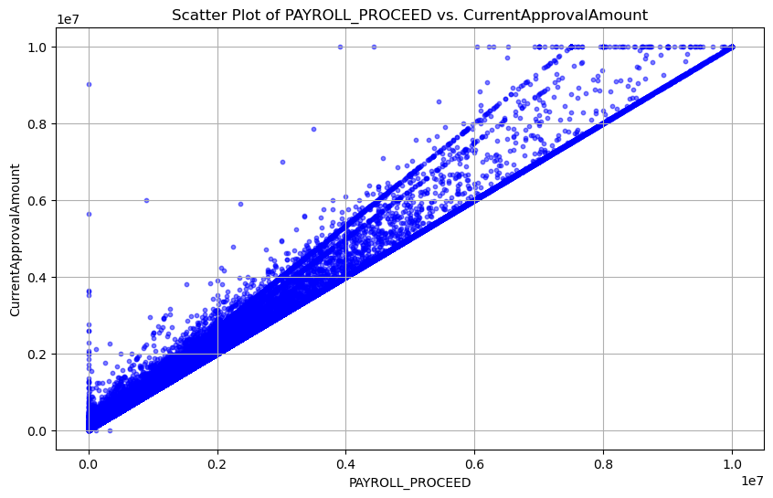

```python
# Question 3c - scatter plot

payroll_approval_data = duckdb.sql('''
SELECT
    PAYROLL_PROCEED,
    CurrentApprovalAmount
FROM
    ppp
WHERE
    PAYROLL_PROCEED IS NOT NULL AND CurrentApprovalAmount IS NOT NULL
''').df()


plt.figure(figsize=(10, 6))
plt.scatter(payroll_approval_data['PAYROLL_PROCEED'], payroll_approval_data['CurrentApprovalAmount'], alpha=0.5, c='blue', s=10)
plt.title('Scatter Plot of PAYROLL_PROCEED vs. CurrentApprovalAmount')
plt.xlabel('PAYROLL_PROCEED')
plt.ylabel('CurrentApprovalAmount')
plt.grid(True)
plt.show()

# The scatter plot shows a clear connection between PAYROLL_PROCEED and CurrentApprovalAmount, suggesting a straightforward linear
# relationship. However, this  trend might be influenced by the way PPP loans were structured, with amounts directly linked
# to payroll figures. While it looks linear, the correlation could be a result of these specific loan formulas rather than a true
# reflection of the underlying data. So, even though the plot indicates a linear pattern, it's important to consider the broader
# context and any complexities within the data.
```

# Problem 4

While Pearson's correlation coefficient can tell us how related two numerical values are - at least linearly, we would like to understand more about how to see how a categorical variable relates to a numerical value.

But we need to be very careful when we are only lookinag at aggregate data: it can mask a lot of things that are happening and some aggregates (such as the average or mean) are highly sensitive to outliers.

Let's try to first see if we can determine, visually, whether there are differences in the distribution of CurrentApprovalAmount between these two NAICS Codes:

Question 4a: Calculate a probability distribution function for CurrentApprovalAmount for both of these two industries. A probability distribution function is like a histogram, but each count should be normalized by the total count, so that we get a "probability" of being in a bin, vs the count. Plot the two using a line/scatter plot where the two lines can fall on top of each other, but with different colors. Based on how the plot looks, feel free to make decisions in bin size, log of axes, etc. to make the plot more visually appealing

```
FloatProgress(value=0.0, layout=Layout(width='auto'), style=ProgressStyle(bar_color='black'))
```

```
FloatProgress(value=0.0, layout=Layout(width='auto'), style=ProgressStyle(bar_color='black'))
```

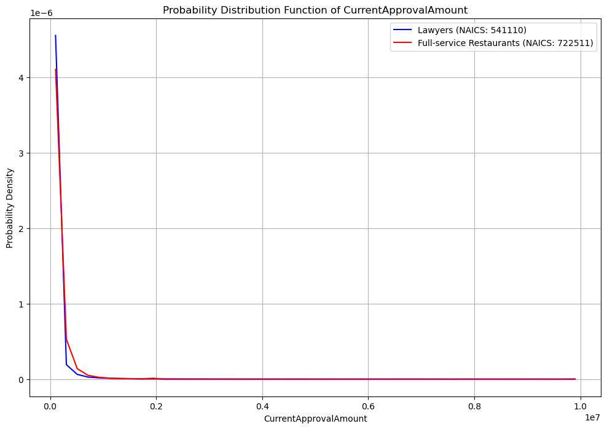

```python
# Question 4a - probability distribution function

import numpy as np

lawyers = duckdb.sql('''
    SELECT CurrentApprovalAmount
    FROM ppp
    WHERE NAICSCode = 541110 AND CurrentApprovalAmount IS NOT NULL
''').df()

restaurants = duckdb.sql('''
    SELECT CurrentApprovalAmount
    FROM ppp
    WHERE NAICSCode = 722511 AND CurrentApprovalAmount IS NOT NULL
''').df()

bins = np.linspace(0, max(lawyers['CurrentApprovalAmount'].max(), restaurants['CurrentApprovalAmount'].max()), 50)
lawyers_hist, _ = np.histogram(lawyers['CurrentApprovalAmount'], bins=bins, density=True)
restaurants_hist, _ = np.histogram(restaurants['CurrentApprovalAmount'], bins=bins, density=True)

bin_centers = (bins[:-1] + bins[1:]) / 2
plt.figure(figsize=(12, 8))
plt.plot(bin_centers, lawyers_hist, label='Lawyers (NAICS: 541110)', color='blue')
plt.plot(bin_centers, restaurants_hist, label='Full-service Restaurants (NAICS: 722511)', color='red')
plt.title('Probability Distribution Function of CurrentApprovalAmount')
plt.xlabel('CurrentApprovalAmount')
plt.ylabel('Probability Density')
plt.legend()
plt.grid(True)
plt.show()
```

# Question 5:

Let's do one more plot, of the same type. But, this time, instead of looking at the CurrentApprovalAmount, let's normalize it by the number of employees, to get something like "Approved Loan Amount per Employee"

Perhaps, even if Lawyers are not typically getting more in total loans, we can see some difference in how much they get paid!

```
FloatProgress(value=0.0, layout=Layout(width='auto'), style=ProgressStyle(bar_color='black'))
```

```
FloatProgress(value=0.0, layout=Layout(width='auto'), style=ProgressStyle(bar_color='black'))
```

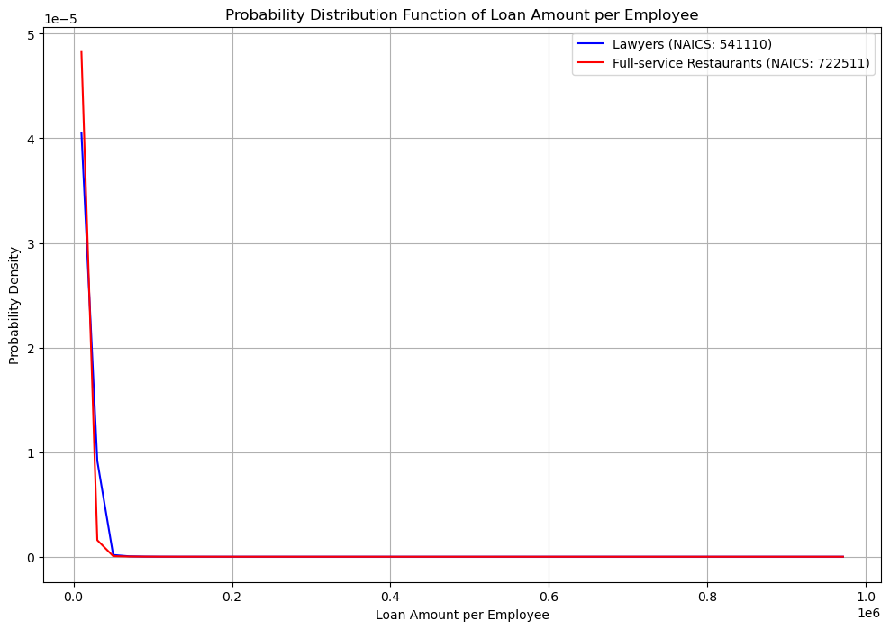

```python
# Question 5 - probability distribution function

lawyers = duckdb.sql('''
    SELECT CurrentApprovalAmount, JobsReported
    FROM ppp
    WHERE NAICSCode = 541110 AND CurrentApprovalAmount IS NOT NULL AND JobsReported IS NOT NULL AND JobsReported > 0
''').df()

lawyers['LoanPerEmployee'] = lawyers['CurrentApprovalAmount'] / lawyers['JobsReported']

restaurants = duckdb.sql('''
    SELECT CurrentApprovalAmount, JobsReported
    FROM ppp
    WHERE NAICSCode = 722511 AND CurrentApprovalAmount IS NOT NULL AND JobsReported IS NOT NULL AND JobsReported > 0
''').df()

restaurants['LoanPerEmployee'] = restaurants['CurrentApprovalAmount'] / restaurants['JobsReported']
bins = np.linspace(0, max(lawyers['LoanPerEmployee'].max(), restaurants['LoanPerEmployee'].max()), 50)
lawyers_hist, _ = np.histogram(lawyers['LoanPerEmployee'], bins=bins, density=True)
restaurants_hist, _ = np.histogram(restaurants['LoanPerEmployee'], bins=bins, density=True)


bin_centers = (bins[:-1] + bins[1:]) / 2
plt.figure(figsize=(12, 8))
plt.plot(bin_centers, lawyers_hist, label='Lawyers (NAICS: 541110)', color='blue')
plt.plot(bin_centers, restaurants_hist, label='Full-service Restaurants (NAICS: 722511)', color='red')
plt.title('Probability Distribution Function of Loan Amount per Employee')
plt.xlabel('Loan Amount per Employee')
plt.ylabel('Probability Density')
plt.legend()
plt.grid(True)
plt.show()
```

# Problem 6

There are a number of other fields in this data set that could be interesting:

Location info: City, State, Zip plus RuralUrbanIndicator Lender: ServicingLenderName Demographics: Race, Ethnicity, Gender Firmographics: BusinessAgeDescription, NonProfit Other Loan details: LoanStatus, Term, ForgivenessAmount

Come up with three additional questions about the data and measure a statistic, make a plot or do some other (quick) analysis to help answer that question.

What kind of gotchas do you come across, such as null or missing values, high cardinality fields, etc.? How do you think you might handle those?

```
FloatProgress(value=0.0, layout=Layout(width='auto'), style=ProgressStyle(bar_color='black'))
```

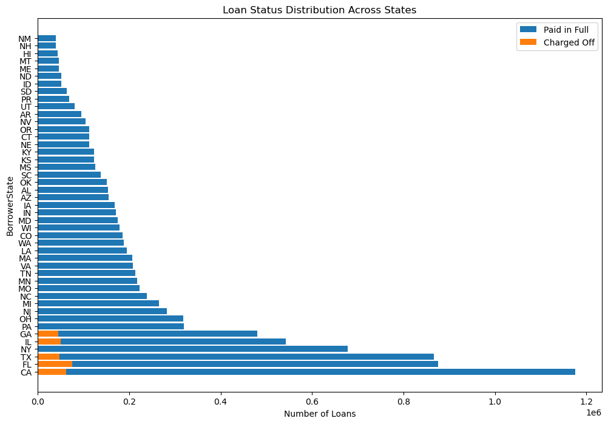

```python
# Calculate loan status distribution by state

loan_status_by_state = duckdb.sql('''
SELECT
    BorrowerState,
    LoanStatus,
    COUNT(*) AS loan_count
FROM
    ppp
GROUP BY
    BorrowerState, LoanStatus
ORDER BY
    loan_count DESC
LIMIT 50
''').df()

plt.figure(figsize=(12, 8))
for status in loan_status_by_state['LoanStatus'].unique():
    subset = loan_status_by_state[loan_status_by_state['LoanStatus'] == status]
    plt.barh(subset['BorrowerState'], subset['loan_count'], label=status)

plt.xlabel('Number of Loans')
plt.ylabel('BorrowerState')
plt.title('Loan Status Distribution Across States')
plt.legend()
plt.show()
```

```
FloatProgress(value=0.0, layout=Layout(width='auto'), style=ProgressStyle(bar_color='black'))
```

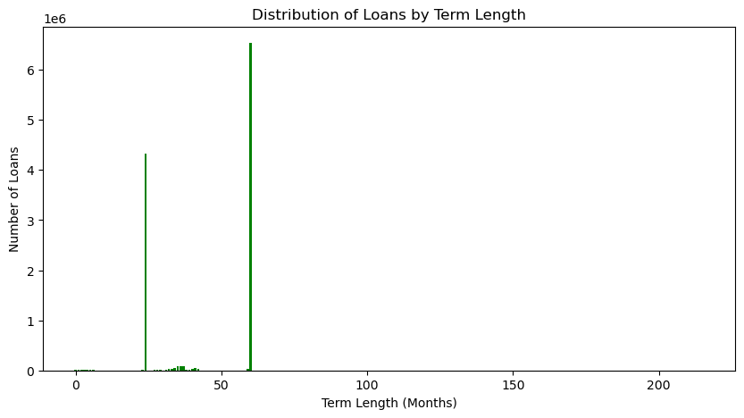

```python
# What is the loan distribution by term length?

term_loans = duckdb.sql('''
SELECT
    Term,
    COUNT(*) AS loan_count
FROM
    ppp
GROUP BY
    Term
ORDER BY
    Term ASC
''').df()

plt.figure(figsize=(10, 5))
plt.bar(term_loans['Term'], term_loans['loan_count'], color='green')
plt.xlabel('Term Length (Months)')
plt.ylabel('Number of Loans')
plt.title('Distribution of Loans by Term Length')
plt.show()
```

```
FloatProgress(value=0.0, layout=Layout(width='auto'), style=ProgressStyle(bar_color='black'))
```

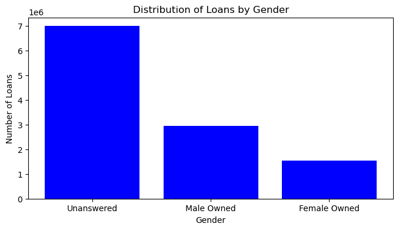

```python
# Calculate loan distribution by Gender

gender_loans = duckdb.sql('''
SELECT
    Gender,
    COUNT(*) AS loan_count
FROM
    ppp
GROUP BY
    Gender
ORDER BY
    loan_count DESC
''').df()

plt.figure(figsize=(8, 4))
plt.bar(gender_loans['Gender'], gender_loans['loan_count'], color='blue')
plt.xlabel('Gender')
plt.ylabel('Number of Loans')
plt.title('Distribution of Loans by Gender')
plt.show()
```